# CRUK CI Summer School 2021 - introduction to single-cell RNA-seq analysis

Quality Control - Challenge

Stephane Ballereau, Ashley Sawle

# 1 Introduction

In the course materials we performed QC and filtering of 2 samples from each of the sample groups. For this challenge we would like you to perform QC and filtering on all of the samples from the Caron data set.

We have prepared a SingleCellExperiment object with the filtered count data from CellRanger already loaded. We have also already added the sample meta data and annotated the genes with their chromosome. Essentially, we have run all the steps up to and including section 6.0.1 in the course materials book.

While running the QC and particularly the filtering, you should consider the experimental set up and will need to decide on whether to apply the filters across all samples at once or whether you should separate the samples into batches for the adapative filters, and at what level the “batch” should be defined.

# 2 Load packages

```r
library(DropletUtils)
library(scater)
library(BiocParallel)
library(tidyverse)
library(patchwork)
library(ggvenn)
library(DT)
```

# 3 Load the data

## 3.1 Sample meta data

We will load both the Caron and HCA data sets. We have already prepared a sample meta data table that relates the sample/run ID to the sample group. This is the metadata for all samples from both data sets.

```r
samplesheet <- read_tsv("../Data/sample_sheet.tsv")
```

```r
samplesheet %>%
    as.data.frame() %>%
    datatable(rownames = FALSE, options = list(dom="tpl", nrows=20))
```

| SampleId | SampleGroup | SampleName | DatasetName |
| --- | --- | --- | --- |
| SRR9264343 | ETV6-RUNX1 | ETV6-RUNX1_1 | Caron |
| SRR9264344 | ETV6-RUNX1 | ETV6-RUNX1_2 | Caron |
| SRR9264345 | ETV6-RUNX1 | ETV6-RUNX1_3 | Caron |
| SRR9264346 | ETV6-RUNX1 | ETV6-RUNX1_4 | Caron |
| SRR9264347 | HHD | HHD_1 | Caron |
| SRR9264348 | HHD | HHD_2 | Caron |
| SRR9264349 | PRE-T | PRE-T_1 | Caron |
| SRR9264350 | PRE-T | PRE-T_2 | Caron |
| SRR9264351 | PBMMC | PBMMC_1 | Caron |
| SRR9264352 | PBMMC | PBMMC_1 | Caron |

[output cut: 10 more lines]

## 3.2 The scRNAseq count data from CellRanger

### 3.2.1 Parallelisation

We first need to first set up some parallel parameters using the package `BiocParallel`.

```r
bp.params <- MulticoreParam(workers = 7)
```

### 3.2.2 Load the data

```r
sce <- readRDS("../Robjects/Caron_data.sce.annot.rds")
```

# 4 QC

## 4.1 Check samples in the data set

Use the `colData` function to check that the samples you have in the `sce` object are the ones you are expecting (all of the Caron data set).

```r
colData(sce) %>%
    as.data.frame() %>%
    select(Sample, SampleId, SampleGroup, DatasetName) %>%
    distinct()
```

|  | Sample | SampleId | SampleGroup | DatasetName |
| --- | --- | --- | --- | --- |
| 1_AAACCTGAGACTTTCG-1 | ETV6-RUNX1_1 | SRR9264343 | ETV6-RUNX1 | Caron |
| 2_AAACCTGAGCAGACTG-1 | ETV6-RUNX1_2 | SRR9264344 | ETV6-RUNX1 | Caron |
| 3_AAACCTGAGGTGATTA-1 | ETV6-RUNX1_3 | SRR9264345 | ETV6-RUNX1 | Caron |
| 4_AAACCTGAGAGTGACC-1 | ETV6-RUNX1_4 | SRR9264346 | ETV6-RUNX1 | Caron |
| 5_AAACCTGAGCCAGAAC-1 | HHD_1 | SRR9264347 | HHD | Caron |
| 6_AAACCTGAGCTAGCCC-1 | HHD_2 | SRR9264348 | HHD | Caron |
| 7_AAACCTGAGAGCTGCA-1 | PRE-T_1 | SRR9264349 | PRE-T | Caron |
| 8_AAACCTGAGAACAACT-1 | PRE-T_2 | SRR9264350 | PRE-T | Caron |
| 9_AAACCTGCACTTCGAA-1 | PBMMC_1a | SRR9264351 | PBMMC | Caron |
| 10_AAACCTGAGATGAGAG-1 | PBMMC_1b | SRR9264352 | PBMMC | Caron |

[output cut: 2 more lines]

# 5 Filter undetected genes

What fraction of the genes are not detected?

```r
detected_genes <- rowSums(counts(sce)) > 0
table(detected_genes)
```

```
detected_genes
FALSE  TRUE
 8224 28377
```

Remove these before proceeding in order to reduce the size of the single cell experiment object.

```r
sce <- sce[detected_genes,]
```

# 6 Quality control

We will look at three QC metrics:

- **library size**
- **number of expressed genes in each cell**
- **proportion of UMIs mapped to genes in the mitochondrial genome**

### 6.0.1 Add per cell QC metrics

Add the per cell QC metrics to the droplet annotation using the function `addPerCellQC`. In order to get the percentage of mitochondrial UMIs in each cell, your will need to pass the function a vector indicating which genes are mitochondrial.

```r
is.mito <- which(rowData(sce)$Chromosome=="MT")

sce <- addPerCellQC(sce, subsets=list(Mito=is.mito), BPPARAM = bp.params)
```

Check that the function has added six columns to the droplet annotation:

- **sum**: total UMI count
- **detected**: number of features (genes) detected
- **subsets_Mito_sum**: number of UMIs mapped to mitochondrial transcripts
- **subsets_Mito_detected**: number of mitochondrial genes detected
- **subsets_Mito_percent**: percentage of reads mapped to mitochondrial transcripts
- **total**: also the total UMI count

```r
head(colData(sce)) %>%
    as.data.frame() %>%
    datatable(rownames = FALSE)
```

| Sample | Barcode | SampleId | SampleGroup | DatasetName | sum | detected | subsets_Mito_sum | subsets_Mito_detected | subsets_Mito_percent | total |
| --- | --- | --- | --- | --- | --- | --- | --- | --- | --- | --- |
| ETV6-RUNX1_1 | AAACCTGAGACTTTCG-1 | SRR9264343 | ETV6-RUNX1 | Caron | 6677 | 2056 | 292 | 12 | 4.37322150666467 | 6677 |
| ETV6-RUNX1_1 | AAACCTGGTCTTCAAG-1 | SRR9264343 | ETV6-RUNX1 | Caron | 12064 | 3177 | 575 | 12 | 4.76624668435013 | 12064 |
| ETV6-RUNX1_1 | AAACCTGGTGCAACTT-1 | SRR9264343 | ETV6-RUNX1 | Caron | 843 | 363 | 428 | 11 | 50.7710557532622 | 843 |
| ETV6-RUNX1_1 | AAACCTGGTGTTGAGG-1 | SRR9264343 | ETV6-RUNX1 | Caron | 8175 | 2570 | 429 | 12 | 5.24770642201835 | 8175 |
| ETV6-RUNX1_1 | AAACCTGTCCCAAGTA-1 | SRR9264343 | ETV6-RUNX1 | Caron | 8638 | 2389 | 526 | 13 | 6.0893725399398 | 8638 |
| ETV6-RUNX1_1 | AAACCTGTCGAATGCT-1 | SRR9264343 | ETV6-RUNX1 | Caron | 1418 | 725 | 91 | 11 | 6.41748942172073 | 1418 |

## 6.1 QC metric distribution

Plot the distributions of the three metrics of interest for each sample. We have given you the code for the **library size**, you will need to modify this for the other two metrics. Check the course materials if you need to figure out which column to use.

### 6.1.1 Library Size

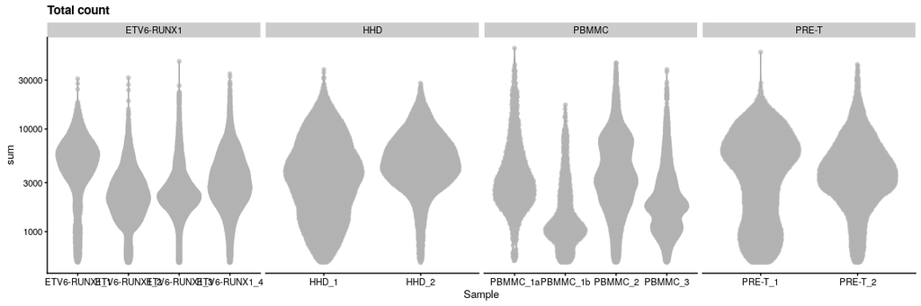

```r
plotColData(sce, x="Sample", y="sum",other_fields="SampleGroup") +
        facet_wrap(~SampleGroup, nrow=1, scales = "free_x") +
        scale_y_log10() +
        ggtitle("Total count")
```

### 6.1.2 Number of Genes detected

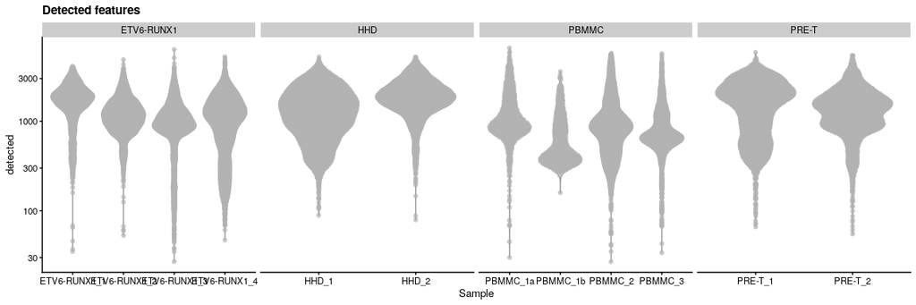

```r
plotColData(sce, x="Sample", y="detected", other_fields="SampleGroup") +
        facet_wrap(~SampleGroup, nrow=1, scales = "free_x") +
        scale_y_log10() +
        ggtitle("Detected features")
```

### 6.1.3 Percentage of UMIs mapped to mitochondrial transcripts

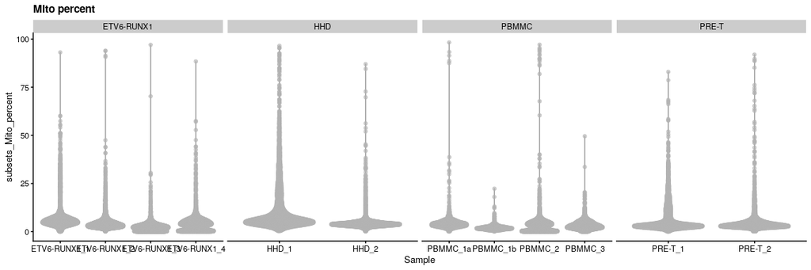

```r
plotColData(sce, x="Sample", y="subsets_Mito_percent", other_fields="SampleGroup") +
        facet_wrap(~SampleGroup, nrow=1, scales = "free_x") +
        ggtitle("Mito percent")
```

# 7 Identification of low-quality cells with adaptive thresholds

First we will apply the adaptive threshold filtering across all samples together. We have given you the code for filtering the by library size, you will need to add the commands for filtering on the number of genes detected and the mitochondrial content (make sure you filter the correct tail of the distribution).

## 7.1 Add the filters

```r
low_lib_size <- isOutlier(sce$sum, log=TRUE, type="lower")
sce$low_lib_size <- low_lib_size
```

### 7.1.1 Number of Genes detected

```r
low_n_features <- isOutlier(sce$detected, log=TRUE, type="lower")
sce$low_n_features <- low_n_features
```

### 7.1.2 Percentage of UMIs mapped to mitochondrial transcripts

```r
high_Mito_percent <- isOutlier(sce$subsets_Mito_percent, type="higher")
sce$high_Mito_percent <- high_Mito_percent
```

## 7.2 Visualise results

Let’s have a look at how these filters would affect the data set.

### 7.2.1 Library Size

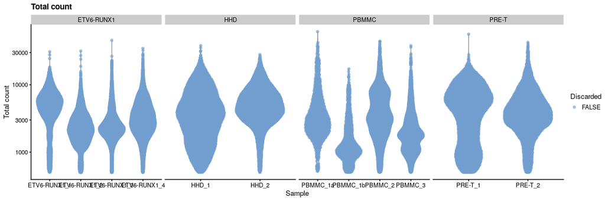

```r
plotColData(sce,
            x="Sample",
            y="sum",
            other_fields="SampleGroup",
            colour_by = "low_lib_size") +
        facet_wrap(~SampleGroup, nrow=1, scales = "free_x") +
        scale_y_log10() +
        labs(y = "Total count", title = "Total count") +
        guides(colour=guide_legend(title="Discarded"))
```

### 7.2.2 Number of Genes detected

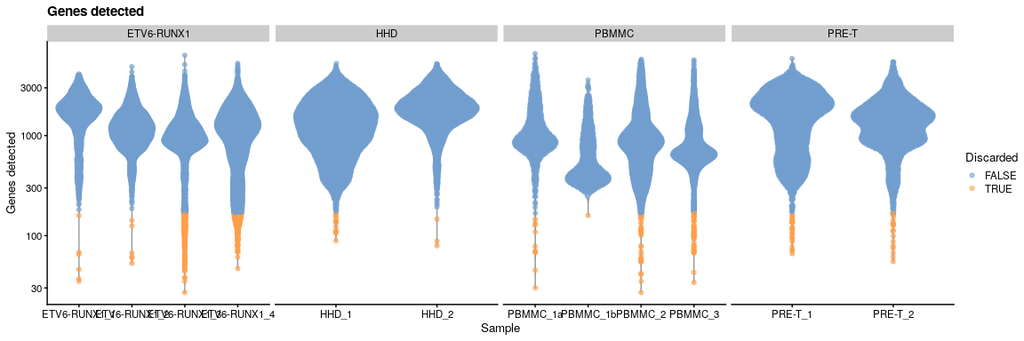

```r
plotColData(sce,
            x="Sample",
            y="detected",
            other_fields="SampleGroup",
            colour_by = "low_n_features") +
        facet_wrap(~SampleGroup, nrow=1, scales = "free_x") +
        scale_y_log10() +
        labs(y = "Genes detected", title = "Genes detected") +
        guides(colour=guide_legend(title="Discarded"))
```

### 7.2.3 Percentage of UMIs mapped to mitochondrial transcripts

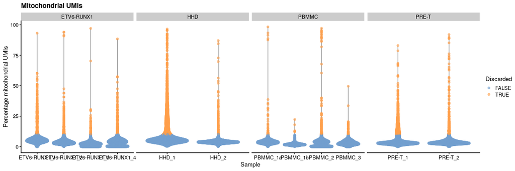

```r
plotColData(sce,
            x="Sample",
            y="subsets_Mito_percent",
            other_fields="SampleGroup",
            colour_by = "high_Mito_percent") +
        facet_wrap(~SampleGroup, nrow=1, scales = "free_x") +
        labs(y = "Percentage mitochondrial UMIs",
             title = "Mitochondrial UMIs") +
        guides(colour=guide_legend(title="Discarded"))
```

# 8 Considering experimental factors when filtering

Based on the experimental design and the plots above, d you think applying the adaptive filtering across all the samples is appropriate?

Perhaps a batched approach is more suitable. This time use the `quickPerCellQC` function to perform all three filters and add a parameter for the batch (this could be any column in the `colData` or you could add a new one).

```r
batch.reasons <- quickPerCellQC(colData(sce),
                                percent_subsets=c("subsets_Mito_percent"),
                                batch=sce$Sample)
```

The table below shows how the thresholds for each metric differ between the batch-wise analysis and the analysis using all samples.

```r
all.thresholds <- tibble(`Batch`="All",
       `Library Size`=attr(low_lib_size, "thresholds")[1],
       `Genes detected`=attr(low_n_features, "thresholds")[1],
       `Mitochondrial UMIs`=attr(high_Mito_percent, "thresholds")[2])


tibble(`Batch`=names(attr(batch.reasons$low_lib_size, "thresholds")[1,]),
       `Library Size`=attr(batch.reasons$low_lib_size, "thresholds")[1,],
       `Genes detected`=attr(batch.reasons$low_n_features, "thresholds")[1,],
       `Mitochondrial UMIs`=attr(batch.reasons$high_subsets_Mito_percent, "thresholds")[2,]) %>%
    bind_rows(all.thresholds) %>%
    mutate(across(where(is.numeric), round, digits=2)) %>%
    datatable(rownames = FALSE)
```

| Batch | Library Size | Genes detected | Mitochondrial UMIs |
| --- | --- | --- | --- |
| ETV6-RUNX1_1 | 1058.29 | 629.11 | 12.33 |
| ETV6-RUNX1_2 | 463.46 | 345.32 | 8.51 |
| ETV6-RUNX1_3 | 712.02 | 336.35 | 7.2 |
| ETV6-RUNX1_4 | 518.05 | 147.88 | 12.94 |
| HHD_1 | 186.18 | 163.36 | 16.69 |
| HHD_2 | 791.93 | 600.45 | 6.92 |
| PBMMC_1a | 398.21 | 284.75 | 8.59 |
| PBMMC_1b | 262.02 | 132.68 | 4.2 |
| PBMMC_2 | 262.04 | 138.05 | 12.17 |
| PBMMC_3 | 256.68 | 244.75 | 8.33 |

[output cut: 3 more lines]

# 9 Filter the data

Once you have decided how best to filter the data you should remove the droplets that do not pass your criteria from the data set.

Replace the filter columns in the droplet annotation with your chosen filters and then create a fourth column that combines the three filters into a single boolean vector.

```r
sce$low_lib_size <- batch.reasons$low_lib_size
sce$low_n_features <- batch.reasons$low_n_features
sce$high_Mito_percent <- batch.reasons$high_subsets_Mito_percent
sce$discard <- sce$low_lib_size | low_n_features | high_Mito_percent
```

Now exclude poor-quality cells from the SingleCellExperiment object and save the final object to the `results` directory for later use.

```r
sce.Filtered <- sce[,!sce$discard]
saveRDS(sce.Filtered, "results/Caron_filtered.rds")
```

[output not shown]

# 10 Optional: Filter genes

You may additionally wish to filter the genes further to remove very sparse genes (see section 12). Remember that you will need to recalculate the colData metrics, as some of them were calculated across all genes. Save this final object as *results/Caron_filtered_genes.rds*.

Generate a table showing the number of genes removed

Filter the genes.

Replace the Cell metrics

# 11 Modify the sample names for PBMMC_1

Remove the suffix letters so that the droplets are assigned to the same sample - note that we can still distinguish the libraries based on the “SampleId” column.

# 12 Export the final obect

Write the object out to a file in the `results` directory for later use.

## 12.1 Session information